# Assignment 2

Kanchan Upadhyay

Assigned Nov 5 2017; Due Nov 10 2017

### 0. Reminder

Use the file naming instructions described at the beginning of assignment 1. This reminder will not be included in subsequent assignments.

### Packages required

```r
require(dplyr)
```

```r
require(ggplot2)
require(tibble)
```

### Problem 1 (1 pt)

1. In your own words, describe what each of the following functions in the dplyr package do.

**a. Filter-** Filter function allows us to subset all obsvervations of a data set based on the values of one or more fields of the data set. As the data is subsetted based on the values of observations, no. of rows are changed.  
**b. Select-** Select function allows us to subset obsvervations of a data set based on the names of the fields of data set. As the data is subsetted based on the field names, no. of columns are changed.  
**c. Arrange-** Arrange function is used to change the order of rows based on the values of specified column/columns. Observations can be arranged in either increasing or decreasing order.  
**d. Mutate-** This function can be used to modify a dataframe by adding new columns to it or modifying existing columns  
**e. Summarise-** Summarise function takes a data frame and operates on the various observations of that data frame to perform the desired operation (for eg.- calculating mean and standard deviation for one or more columns of a data frame) and return a single row as output. It is more useful when used in conjunction with group_by function.  
**f. One_of-**This function can be used to select observations based on the presense of desired variables in a character vector

### Problem 2 (1 pt)

Find all flights from the “flights” data in the “nycflights13” package that

```r
require(nycflights13)
```

- Departed early

```r
flights_dep_early<-filter(flights,dep_delay<0)
```

- Flew to Pittsburgh (PIT) and arrived lat_e

```r
flights_pitt_late<-filter(flights,dest=="PIT",arr_delay>0)
```

- Departed early from in New York (LGA, JFK)

```r
flights_ny_early<-filter(flights,origin=="LGA"|origin=="JFK",dep_delay<0)
```

- Departed in the morning

```r
flights_morning<-filter(flights,dep_time<1200)
```

- Arrived more minutes late then they left early. (Think carefully about this one!)

```r
flights_delay<-filter(flights,arr_delay>0,dep_delay<0,arr_delay>-(dep_delay))
```

### Problem 3 (6 pts)

In this problem, we will use the Residential Energy Consumption Survey (RECS) to explore what influences energy used for heating in single-family homes. RECS is a regular survey of energy consumption in U.S. households (https://www.eia.gov/consumption/residential/). I have included a cleaned version of the household-level responses (the “microdata”) at “https://s3.amazonaws.com/aws-website-programminginrforanalytics-tbal0/data/RECS.csv”

If you explore the RECS data, youâll see that there are over 500 fields published for each household. You will be substantially manipulating the raw RECS data. As a result, you may find it easier to occasionally create new objects for use in subsequent steps so as to avoid having to repeat lines of code when you make errors. There are no prescribed rules for when to create new objects versus modify existing objects. You’ll just have to exercise judgement. Reflect any subsetting you perform in subsequent steps.

```r
energy<-read.csv("https://s3.amazonaws.com/aws-website-programminginrforanalytics-tbal0/data/RECS.csv")
```

1. Select only the following variables from the dta
- TOTHSQFT = floorspace heated in square feet
- ADQINSUL = a factor variable (ordinal) indicating level of insulation
- REPORTABLE_DOMAIN = smallest geography reported while preserving confidentiality
- TOTALBTUSPH = total amount of energy used for heating in British Thermal Units (BTU)
- EQUIPAGE = Age of heating equipment
- PROTHERM = Indicates the use of a programmable thermostat
- TYPEHUQ = Type of household
- FUELHEAT = Energy source for heating
- EQUIPM = Type of equipment using for heating

```r
energy_sub<-as.tibble(select(energy,TOTHSQFT,ADQINSUL,REPORTABLE_DOMAIN,TOTALBTUSPH,EQUIPAGE,PROTHERM,TYPEHUQ,FUELHEAT,EQUIPM))
energy_sub
```

```
## # A tibble: 12,083 x 9
##    TOTHSQFT             ADQINSUL
##       <int>               <fctr>
##  1     3958       Well Insulated
##  2     2736     Poorly Insulated
##  3      528 Adequately Insulated
##  4     1623       Well Insulated
##  5     1274 Adequately Insulated
##  6     3485 Adequately Insulated
##  7     2296     Poorly Insulated
##  8     1952     Poorly Insulated
##  9     1117       Well Insulated
## 10     1365 Adequately Insulated
## # ... with 12,073 more rows, and 7 more variables:
## #   REPORTABLE_DOMAIN <fctr>, TOTALBTUSPH <int>, EQUIPAGE <fctr>,
## #   PROTHERM <fctr>, TYPEHUQ <fctr>, FUELHEAT <fctr>, EQUIPM <fctr>
```

2. Using dplyr functions, use two different approaches to selecting only single family homes, not including mobile homes. In one approach, use the “or” operator, “|.” In the other, use the “%in%” operator.  
   **Using “Or” operator**

```r
energy_single<-as.tibble(filter(energy_sub,TYPEHUQ=="Single-Family Attached"|TYPEHUQ=="Single-Family Detached"))
energy_single
```

```
## # A tibble: 8,693 x 9
##    TOTHSQFT             ADQINSUL
##       <int>               <fctr>
##  1     3958       Well Insulated
##  2     2736     Poorly Insulated
##  3     1623       Well Insulated
##  4     1274 Adequately Insulated
##  5     3485 Adequately Insulated
##  6     2296     Poorly Insulated
##  7     1952     Poorly Insulated
##  8     1117       Well Insulated
##  9     1365 Adequately Insulated
## 10     1935 Adequately Insulated
## # ... with 8,683 more rows, and 7 more variables:
## #   REPORTABLE_DOMAIN <fctr>, TOTALBTUSPH <int>, EQUIPAGE <fctr>,
## #   PROTHERM <fctr>, TYPEHUQ <fctr>, FUELHEAT <fctr>, EQUIPM <fctr>
```

**Using “%in%” operator**

```r
energy_single<-as.tibble(filter(energy_sub,TYPEHUQ%in%c("Single-Family Attached","Single-Family Detached")))
energy_single
```

```
## # A tibble: 8,693 x 9
##    TOTHSQFT             ADQINSUL
##       <int>               <fctr>
##  1     3958       Well Insulated
##  2     2736     Poorly Insulated
##  3     1623       Well Insulated
##  4     1274 Adequately Insulated
##  5     3485 Adequately Insulated
##  6     2296     Poorly Insulated
##  7     1952     Poorly Insulated
##  8     1117       Well Insulated
##  9     1365 Adequately Insulated
## 10     1935 Adequately Insulated
## # ... with 8,683 more rows, and 7 more variables:
## #   REPORTABLE_DOMAIN <fctr>, TOTALBTUSPH <int>, EQUIPAGE <fctr>,
## #   PROTHERM <fctr>, TYPEHUQ <fctr>, FUELHEAT <fctr>, EQUIPM <fctr>
```

3. Using dplyr functions, add a field that displays heating energy used per sq ft of floor space. Why does the function return “NaN” for some homes?

```r
energy_single<-as.tibble(mutate(energy_single,ENERGYSQFT=TOTALBTUSPH/TOTHSQFT))
energy_single
```

```
## # A tibble: 8,693 x 10
##    TOTHSQFT             ADQINSUL
##       <int>               <fctr>
##  1     3958       Well Insulated
##  2     2736     Poorly Insulated
##  3     1623       Well Insulated
##  4     1274 Adequately Insulated
##  5     3485 Adequately Insulated
##  6     2296     Poorly Insulated
##  7     1952     Poorly Insulated
##  8     1117       Well Insulated
##  9     1365 Adequately Insulated
## 10     1935 Adequately Insulated
## # ... with 8,683 more rows, and 8 more variables:
## #   REPORTABLE_DOMAIN <fctr>, TOTALBTUSPH <int>, EQUIPAGE <fctr>,
## #   PROTHERM <fctr>, TYPEHUQ <fctr>, FUELHEAT <fctr>, EQUIPM <fctr>,
## #   ENERGYSQFT <dbl>
```

*NaN means“Not a number”.This is displayed when math function fail. In the Energy per sqft calculation, NaN is displayed when the division operator used to calculated it fails and this happens when either Total squarefeet data is 0 or both Total energy(TOTALBTUSPH) and total squarefeet data(TOTHSQFT) are 0.*

4. Use the “ifelse” function to assign a value of 0 to any observation where btu.per.sqft is “NaN.” Note the function “is.nan()” returns a logical value of TRUE if the argument is NaN. It performs similarly to is.na().

```r
energy_single<-as.tibble(mutate(energy_single,ENERGYSQFT=if_else(is.nan(ENERGYSQFT),0,ENERGYSQFT)))
energy_single
```

```
## # A tibble: 8,693 x 10
##    TOTHSQFT             ADQINSUL
##       <int>               <fctr>
##  1     3958       Well Insulated
##  2     2736     Poorly Insulated
##  3     1623       Well Insulated
##  4     1274 Adequately Insulated
##  5     3485 Adequately Insulated
##  6     2296     Poorly Insulated
##  7     1952     Poorly Insulated
##  8     1117       Well Insulated
##  9     1365 Adequately Insulated
## 10     1935 Adequately Insulated
## # ... with 8,683 more rows, and 8 more variables:
## #   REPORTABLE_DOMAIN <fctr>, TOTALBTUSPH <int>, EQUIPAGE <fctr>,
## #   PROTHERM <fctr>, TYPEHUQ <fctr>, FUELHEAT <fctr>, EQUIPM <fctr>,
## #   ENERGYSQFT <dbl>
```

5. Sort the recs data so that homes with missing values for PROTHERM are on the top and review the results.

```r
energy_single<- as.tibble(arrange(energy_single,!is.na(PROTHERM)))
energy_single
```

```
## # A tibble: 8,693 x 10
##    TOTHSQFT             ADQINSUL
##       <int>               <fctr>
##  1        0     Poorly Insulated
##  2        0     Poorly Insulated
##  3        0 Adequately Insulated
##  4     1437     Poorly Insulated
##  5     1323     Poorly Insulated
##  6        0        No Insulation
##  7     2111       Well Insulated
##  8      720 Adequately Insulated
##  9     1088       Well Insulated
## 10     2016 Adequately Insulated
## # ... with 8,683 more rows, and 8 more variables:
## #   REPORTABLE_DOMAIN <fctr>, TOTALBTUSPH <int>, EQUIPAGE <fctr>,
## #   PROTHERM <fctr>, TYPEHUQ <fctr>, FUELHEAT <fctr>, EQUIPM <fctr>,
## #   ENERGYSQFT <dbl>
```

6. You can see that many homes without programmable thermostats burn wood in a heating stove for heat. Wood use is less accurate than use of electricity or natural gas, which is metered by a utility company. Remove all records that use an energy source other than electricity or natural gas.

```r
energy_single<-filter(energy_single,FUELHEAT%in%c("Electricity","Natural Gas"))
energy_single
```

```
## # A tibble: 7,150 x 10
##    TOTHSQFT             ADQINSUL                  REPORTABLE_DOMAIN
##       <int>               <fctr>                             <fctr>
##  1     1323     Poorly Insulated                              Texas
##  2      720 Adequately Insulated                          Tennessee
##  3     1088       Well Insulated                           New York
##  4     2016 Adequately Insulated Alaska, Hawaii, Oregon, Washington
##  5      437     Poorly Insulated                         California
##  6      437     Poorly Insulated                              Texas
##  7     3900 Adequately Insulated                      Indiana, Ohio
##  8      690     Poorly Insulated     North Carolina, South Carolina
##  9     1286     Poorly Insulated     Alabama, Kentucky, Mississippi
## 10      800 Adequately Insulated                              Texas
## # ... with 7,140 more rows, and 7 more variables: TOTALBTUSPH <int>,
## #   EQUIPAGE <fctr>, PROTHERM <fctr>, TYPEHUQ <fctr>, FUELHEAT <fctr>,
## #   EQUIPM <fctr>, ENERGYSQFT <dbl>
```

7. Find the mean and standard deviation of energy consumption used by reportable geographic domain and include a count of observations by group.

```r
energy_single_consumption<-energy_single%>%group_by(REPORTABLE_DOMAIN)%>%summarise(mean_energy=mean(ENERGYSQFT),sd_energy=sd(ENERGYSQFT),count=n())
energy_single_consumption
```

```
## # A tibble: 27 x 4
##                                           REPORTABLE_DOMAIN mean_energy
##                                                      <fctr>       <dbl>
##  1                           Alabama, Kentucky, Mississippi   17.027192
##  2                       Alaska, Hawaii, Oregon, Washington   28.787818
##  3                                                  Arizona    6.078949
##  4                            Arkansas, Louisiana, Oklahoma   21.006567
##  5                                               California   17.041078
##  6                                                 Colorado   34.796295
##  7 Connecticut, Maine, New Hampshire, Rhode Island, Vermont   43.461744
##  8  Delaware, District of Columbia, Maryland, West Virginia   20.082686
##  9                                                  Florida    3.362499
## 10                                                  Georgia   16.433489
## # ... with 17 more rows, and 2 more variables: sd_energy <dbl>,
## #   count <int>
```

8. Using the summary table from step g, print a table that shows the geographies with the 10 highest heating energy use per square foot. Why do you think these areas are relatively high?

```r
energy_single_consumption<-arrange(energy_single_consumption,-mean_energy)
energy_single_consumption<-select(energy_single_consumption,REPORTABLE_DOMAIN,mean_energy)
head(energy_single_consumption,10)
```

```
## # A tibble: 10 x 2
##                                           REPORTABLE_DOMAIN mean_energy
##                                                      <fctr>       <dbl>
##  1                                                 Michigan    51.78519
##  2 Connecticut, Maine, New Hampshire, Rhode Island, Vermont    43.46174
##  3                                                 New York    41.49110
##  4                                                 Illinois    38.32377
##  5                                            Massachusetts    37.03695
##  6                                         Kansas, Nebraska    36.52353
##  7                                               New Jersey    35.71007
##  8                                                Wisconsin    35.20609
##  9                                            Indiana, Ohio    35.12858
## 10                                                 Colorado    34.79630
```

*One of the reasons why Energy consumption for above areas are relatively high compared to other areas could be that these areas are colder than other areas.*

1. Let’s remove homes without any energy used for heating. Why might we want to do this? We do this because all of the homes with zero consumption are not readily comparable to those with consumption. In a more sophisticated approach, we might develop a two-stage model where we predict those homes that have some consumption, then use those predictions in a subsequent model that explains consumption. However, this approach is well beyond the scope of this course.

```r
energy_single<-filter(energy_single,TOTALBTUSPH!=0)
energy_single
```

```
## # A tibble: 7,150 x 10
##    TOTHSQFT             ADQINSUL                  REPORTABLE_DOMAIN
##       <int>               <fctr>                             <fctr>
##  1     1323     Poorly Insulated                              Texas
##  2      720 Adequately Insulated                          Tennessee
##  3     1088       Well Insulated                           New York
##  4     2016 Adequately Insulated Alaska, Hawaii, Oregon, Washington
##  5      437     Poorly Insulated                         California
##  6      437     Poorly Insulated                              Texas
##  7     3900 Adequately Insulated                      Indiana, Ohio
##  8      690     Poorly Insulated     North Carolina, South Carolina
##  9     1286     Poorly Insulated     Alabama, Kentucky, Mississippi
## 10      800 Adequately Insulated                              Texas
## # ... with 7,140 more rows, and 7 more variables: TOTALBTUSPH <int>,
## #   EQUIPAGE <fctr>, PROTHERM <fctr>, TYPEHUQ <fctr>, FUELHEAT <fctr>,
## #   EQUIPM <fctr>, ENERGYSQFT <dbl>
```

10. Prepare a scatter plot showing heating energy used (y-axis) as a function of heated floorspace (x-axis). On average, do larger homes use more energy for heating?

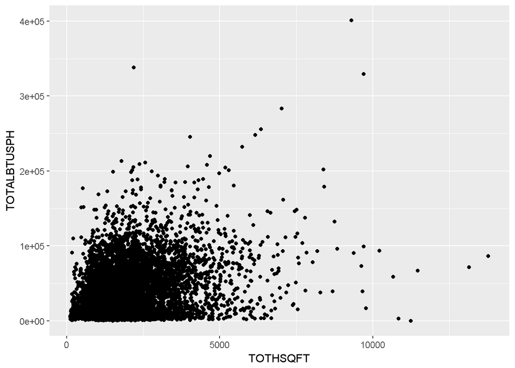

```r
energy_vs_floorspace<-ggplot(data=energy_single)+geom_point(mapping=aes(x=TOTHSQFT,y=TOTALBTUSPH))
energy_vs_floorspace
```

*Yes on average, larger home use more energy for heating, however size is not the only factor determining the energy consumed. As we can see from the graph, for similar square feet area,the total energy consumed vary a lot.*

11. Now prepare separate scatterplots of heating energy used as a function of floorspace, one plot for each response of equipment age. Add to these plots a linear regression line.

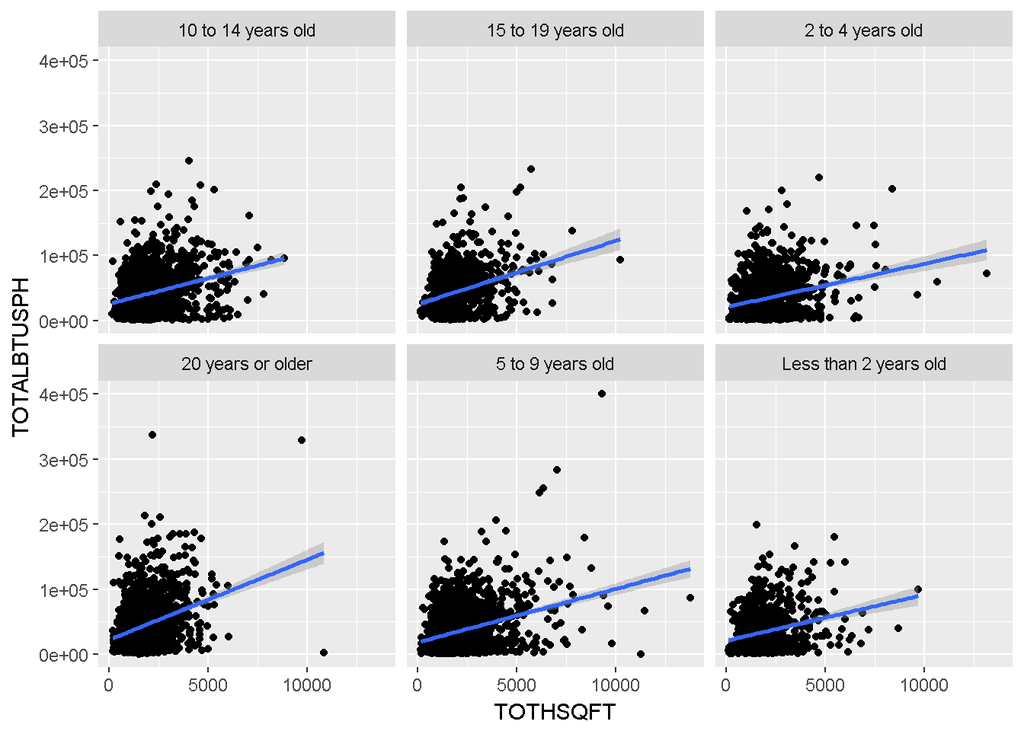

```r
ggplot(data=energy_single)+geom_point(mapping = aes(x=TOTHSQFT,y=TOTALBTUSPH))+facet_wrap(~EQUIPAGE,nrow=2)+geom_smooth(mapping = aes(x=TOTHSQFT,y=TOTALBTUSPH),method = lm)
```

12. By inspection, you can some extreme values for both energy consumption and floorspace that are likely outliers. Remove all observations where consumption and floorspace are greater than 300,000 BTU and 10,000 sq ft, respectively, and generate the plots again. By inspection, does newer or older heating equipment use more or less energy? Why do you think that is?

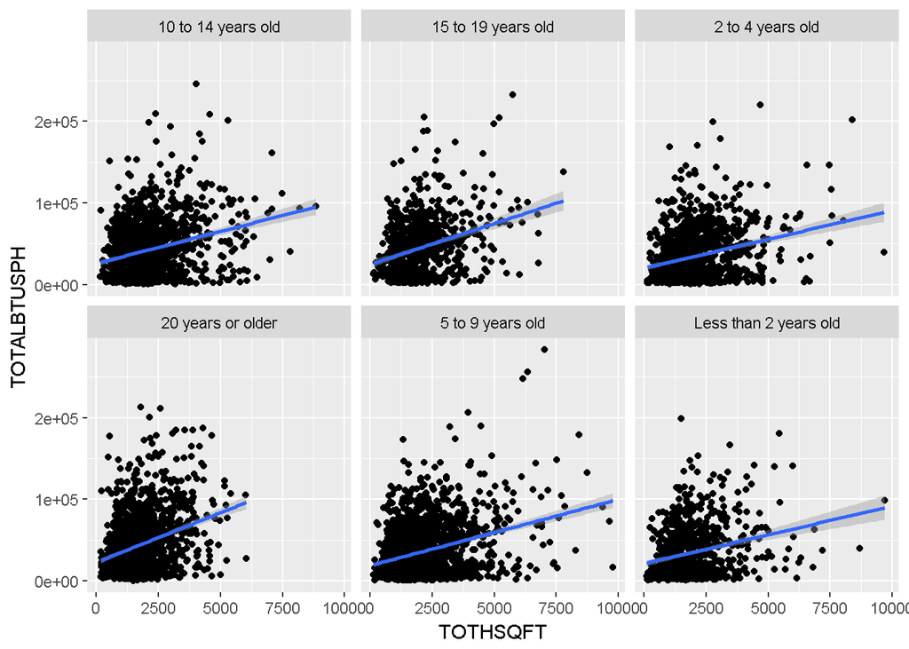

```r
energy_single<-filter(energy_single,TOTHSQFT<=10000,TOTALBTUSPH<=300000)
ggplot(data=energy_single)+geom_point(mapping = aes(x=TOTHSQFT,y=TOTALBTUSPH))+facet_wrap(~EQUIPAGE,nrow=2)+geom_smooth(mapping = aes(x=TOTHSQFT,y=TOTALBTUSPH),method = lm)
```

*By inspection, it looks like for same square feet area, the energy consumed for older heating equipment is more. This can be due to the fact that efficiency of any equipment decreases with time so its energy consumption increases.*  
m. Let’s reorder the factor levels and redefine the labels for EQUIPAGE and ADQINSUL. I have included the code for doing for EQUIPAGE. Using the code provided for EQUIPAGE as a guide, reorder ADQINSUL in order of decreasing amounts of insulation and rename the factors so their description is shorter.

```r
energy_single$EQIPAGE<-factor(energy_single$EQUIPAGE,levels = c("Less than 2 years old", "2 to 4 years old", "5 to 9 years old",                                                          "10 to 14 years old", "15 to 19 years old", "20 years or older"),labels = c("<2","2-4","5-9","10-14","15-19",">20"))
energy_single$ADQINSUL<-factor(energy_single$ADQINSUL,levels = c("No Insulation", "Poorly Insulated", "Adequately Insulated",                                                          "Well Insulated"),labels = c("No","Poor","Adequate","Well"))
```

14. Now prepare a boxplot with equipment age on the x-axis, energy use PER SQUARE FOOT, on the y axis, and color code the plot by the presence the degree of insulation. How does insulation appear to effect consumption?

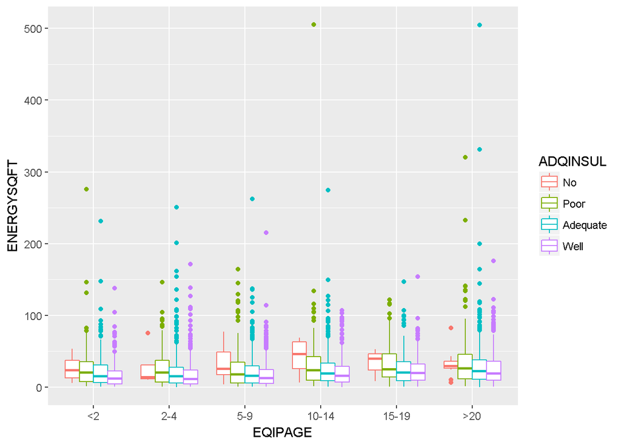

```r
ggplot(data=energy_single)+geom_boxplot(mapping = aes(x=EQIPAGE,y=ENERGYSQFT,color=ADQINSUL))
```

*Energy consumption per square feet is maximum if the house has no insulation or poor insulation and decreases as insulation gets better.*